# Ajinkya Kobal_Project-15_Regression Analysis

### 16.1) Log transformation

```python
import numpy as np
merge_ind['norm'] = (1+merge_ind.revt)/2
merge_ind['log_revt'] = np.log(merge_ind['norm'])
merge_ind.head()
```

|  | cik | gvkey | datadate | conm | revt | ni | year | month | House_price | Interest_rate | ... | y_2015 | y_2016 | y_2017 | y_2018 | y_2019 | y_2020 | y_2021 | y_2022 | Real_income | log_revt |
| --- | --- | --- | --- | --- | --- | --- | --- | --- | --- | --- | --- | --- | --- | --- | --- | --- | --- | --- | --- | --- | --- |
| 1 | 0001408100 | 025632 | 2000-12-31 | KENNEDY-WILSON HOLDINGS INC | 92.737 | 4.726 | 2000 | 12 | 104.777000 | 3.116589 | ... | False | False | False | False | False | False | False | False | 11677.540167 | 3.847346 |
| 25 | 0001408100 | 025632 | 2001-12-31 | KENNEDY-WILSON HOLDINGS INC | 60.228 | 2.357 | 2001 | 12 | 113.185583 | 2.237448 | ... | False | False | False | False | False | False | False | False | 11942.774917 | 3.421457 |
| 44 | 0001408100 | 025632 | 2002-12-31 | KENNEDY-WILSON HOLDINGS INC | 44.662 | 6.165 | 2002 | 12 | 122.287833 | 2.033603 | ... | False | False | False | False | False | False | False | False | 11993.402917 | 3.128119 |
| 57 | 0001408100 | 025632 | 2003-12-31 | KENNEDY-WILSON HOLDINGS INC | 27.094 | 5.382 | 2003 | 12 | 133.741167 | 1.445796 | ... | False | False | False | False | False | False | False | False | 12172.098333 | 2.642409 |
| 66 | 0001408100 | 025632 | 2004-12-31 | KENNEDY-WILSON HOLDINGS INC | 42.036 | 4.115 | 2004 | 12 | 150.464167 | 1.700858 | ... | False | False | False | False | False | False | False | False | 12545.784583 | 3.068890 |

5 rows × 51 columns

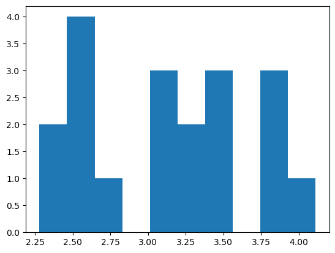

```python
import matplotlib.pyplot as plt

plt.hist(merge_ind['log_revt'])
plt.show()
```

**Observation : After Log Regression revenue is evenly Distributed**

```python
merge_ind.describe()
```

|  | datadate | revt | ni | year | month | House_price | Interest_rate | norm | log_Interest_rate | Real_income | log_revt |
| --- | --- | --- | --- | --- | --- | --- | --- | --- | --- | --- | --- |
| count | 23 | 19.000000 | 19.000000 | 23.00000 | 23.0 | 23.000000 | 23.000000 | 19.000000 | 23.000000 | 23.000000 | 19.000000 |
| mean | 2002-12-31 03:07:49.565217408 | 51.448368 | 1.385632 | 2002.00000 | 12.0 | 121.583688 | 2.151892 | 26.224184 | 0.378467 | 11765.908899 | 3.127218 |
| min | 1991-12-31 00:00:00 | 18.546000 | -15.336000 | 1991.00000 | 12.0 | 75.925417 | -0.013249 | 9.773000 | -0.706485 | 8239.163500 | 2.279623 |
| 25% | 1997-07-01 12:00:00 | 26.375500 | 0.656000 | 1996.50000 | 12.0 | 84.063500 | 1.373753 | 13.687750 | 0.170864 | 9839.512500 | 2.616157 |
| 50% | 2002-12-31 00:00:00 | 45.182000 | 4.030000 | 2002.00000 | 12.0 | 122.287833 | 2.237448 | 23.091000 | 0.481638 | 11993.402917 | 3.139443 |
| 75% | 2008-07-01 00:00:00 | 63.344500 | 5.353500 | 2007.50000 | 12.0 | 149.508708 | 3.128320 | 32.172250 | 0.724719 | 13673.250292 | 3.471043 |
| max | 2013-12-31 00:00:00 | 121.200000 | 6.346000 | 2013.00000 | 12.0 | 183.481417 | 3.933928 | 61.100000 | 0.902988 | 14721.863750 | 4.112512 |
| std | NaN | 28.650010 | 6.304810 | 6.78233 | 0.0 | 36.853620 | 1.112895 | 14.325005 | 0.429540 | 2137.351617 | 0.546816 |

```python
Qmodel2=smf.ols(formula='log_revt~House_price',data=merge_ind)
Qresults2=Qmodel2.fit()
print(Qresults2.summary())
```

```
                            OLS Regression Results
==============================================================================
Dep. Variable:               log_revt   R-squared:                       0.373
Model:                            OLS   Adj. R-squared:                  0.336
Method:                 Least Squares   F-statistic:                     10.10
Date:                Mon, 04 Dec 2023   Prob (F-statistic):            0.00550
Time:                        03:12:27   Log-Likelihood:                -10.546
No. Observations:                  19   AIC:                             25.09
Df Residuals:                      17   BIC:                             26.98
Df Model:                           1
Covariance Type:            nonrobust
===============================================================================
                  coef    std err          t      P>|t|      [0.025      0.975]
-------------------------------------------------------------------------------
Intercept       1.8887      0.403      4.688      0.000       1.039       2.739
House_price     0.0112      0.004      3.178      0.005       0.004       0.019
==============================================================================
Omnibus:                        0.575   Durbin-Watson:                   1.125
Prob(Omnibus):                  0.750   Jarque-Bera (JB):                0.648
Skew:                           0.300   Prob(JB):                        0.723
Kurtosis:                       2.322   Cond. No.                         450.
==============================================================================

Notes:
[1] Standard Errors assume that the covariance matrix of the errors is correctly specified.
```

**Observation :**

**1) Prob (F-statistic) - This value is <0.1, so we will consider this regression analysis.**

**2) R-squared - Value is significant as it is between 0 to 1.**

**3) coef - Value is Positive.**

### 16.2) Control variables

```python
Qwhat1=pd.get_dummies(datamerge['year'], prefix='x')
merge_ind = merge_ind.merge(Qwhat1, how='inner', left_index=True, right_index=True)
merge_ind.head()
```

|  | cik | gvkey | datadate | conm | revt | ni | year | month | House_price | Interest_rate | ... | x_2013 | x_2014 | x_2015 | x_2016 | x_2017 | x_2018 | x_2019 | x_2020 | x_2021 | x_2022 |
| --- | --- | --- | --- | --- | --- | --- | --- | --- | --- | --- | --- | --- | --- | --- | --- | --- | --- | --- | --- | --- | --- |
| 1 | 0001408100 | 025632 | 2000-12-31 | KENNEDY-WILSON HOLDINGS INC | 92.737 | 4.726 | 2000 | 12 | 104.777000 | 3.116589 | ... | False | False | False | False | False | False | False | False | False | False |
| 25 | 0001408100 | 025632 | 2001-12-31 | KENNEDY-WILSON HOLDINGS INC | 60.228 | 2.357 | 2001 | 12 | 113.185583 | 2.237448 | ... | False | False | False | False | False | False | False | False | False | False |
| 44 | 0001408100 | 025632 | 2002-12-31 | KENNEDY-WILSON HOLDINGS INC | 44.662 | 6.165 | 2002 | 12 | 122.287833 | 2.033603 | ... | False | False | False | False | False | False | False | False | False | False |
| 57 | 0001408100 | 025632 | 2003-12-31 | KENNEDY-WILSON HOLDINGS INC | 27.094 | 5.382 | 2003 | 12 | 133.741167 | 1.445796 | ... | False | False | False | False | False | False | False | False | False | False |
| 66 | 0001408100 | 025632 | 2004-12-31 | KENNEDY-WILSON HOLDINGS INC | 42.036 | 4.115 | 2004 | 12 | 150.464167 | 1.700858 | ... | False | False | False | False | False | False | False | False | False | False |

5 rows × 88 columns

```python
Qmodel3 = smf.ols(formula='log_revt ~ House_price+y_2006+y_2007+y_2008+y_2009+y_2010', data=datamerge)
Qresults3 =Qmodel3.fit()
print(Qresults3.summary())
```

```
                            OLS Regression Results
==============================================================================
Dep. Variable:               log_revt   R-squared:                       0.242
Model:                            OLS   Adj. R-squared:                  0.234
Method:                 Least Squares   F-statistic:                     29.63
Date:                Mon, 04 Dec 2023   Prob (F-statistic):           7.50e-31
Time:                        03:15:07   Log-Likelihood:                -1242.4
No. Observations:                 563   AIC:                             2499.
Df Residuals:                     556   BIC:                             2529.
Df Model:                           6
Covariance Type:            nonrobust
==================================================================================
                     coef    std err          t      P>|t|      [0.025      0.975]
----------------------------------------------------------------------------------
Intercept          1.4589      0.243      6.007      0.000       0.982       1.936
y_2006[T.True]     0.2388      0.649      0.368      0.713      -1.036       1.513
y_2007[T.True]    -0.0373      0.624     -0.060      0.952      -1.262       1.188
y_2008[T.True]     0.5591      0.580      0.963      0.336      -0.581       1.699
y_2009[T.True]     0.3197      0.580      0.551      0.582      -0.819       1.459
y_2010[T.True]     0.0465      0.546      0.085      0.932      -1.025       1.119
House_price        0.0199      0.002     13.114      0.000       0.017       0.023
==============================================================================
Omnibus:                       37.118   Durbin-Watson:                   1.894
Prob(Omnibus):                  0.000   Jarque-Bera (JB):               42.495
Skew:                          -0.659   Prob(JB):                     5.92e-10
Kurtosis:                       2.730   Cond. No.                     1.13e+03
==============================================================================

Notes:
[1] Standard Errors assume that the covariance matrix of the errors is correctly specified.
[2] The condition number is large, 1.13e+03. This might indicate that there are
strong multicollinearity or other numerical problems.
```

**Observation :**

**1) Prob (F-statistic) - This value is <0.1, so we will consider this regression analysis.**

**2) R-squared - Value is significant as it is between 0 to 1.**

**3) coef - Value is Positive.**

# 17) KENNEDY-WILSON HOLDINGS (Revenue & Interest Rate/Year.)====

```python
Rmodel1=smf.ols(formula='revt~Interest_rate+year',data=merge_ind)
Rresults1=Rmodel1.fit()
print(Rresults1.summary())
```

```
                            OLS Regression Results
==============================================================================
Dep. Variable:                   revt   R-squared:                       0.576
Model:                            OLS   Adj. R-squared:                  0.523
Method:                 Least Squares   F-statistic:                     10.89
Date:                Mon, 04 Dec 2023   Prob (F-statistic):            0.00104
Time:                        03:46:28   Log-Likelihood:                -82.033
No. Observations:                  19   AIC:                             170.1
Df Residuals:                      16   BIC:                             172.9
Df Model:                           2
Covariance Type:            nonrobust
=================================================================================
                    coef    std err          t      P>|t|      [0.025      0.975]
---------------------------------------------------------------------------------
Intercept      -1.62e+04   4785.024     -3.385      0.004   -2.63e+04   -6053.640
Interest_rate    33.3159     13.954      2.388      0.030       3.735      62.897
year              8.0834      2.376      3.401      0.004       3.046      13.121
==============================================================================
Omnibus:                        0.858   Durbin-Watson:                   1.842
Prob(Omnibus):                  0.651   Jarque-Bera (JB):                0.822
Skew:                           0.317   Prob(JB):                        0.663
Kurtosis:                       2.202   Cond. No.                     2.11e+06
==============================================================================

Notes:
[1] Standard Errors assume that the covariance matrix of the errors is correctly specified.
[2] The condition number is large, 2.11e+06. This might indicate that there are
strong multicollinearity or other numerical problems.
```

**Observation:**

**(Result interpretation on regression Prob (F-statistic) is less than 0.1, this regression analysis can be considered.)**

**R-squared is 0.576 - i.e. 57% of revenue is explained by independent variables.**

## Regression for log_revt ~ Interest_rate + House_price + Real_income

```python
Smodel1 = smf.ols(formula='log_revt ~ Interest_rate + House_price + Real_income', data=merge_ind)
Qresults12 = Smodel1.fit()
print(Qresults12.summary())
```

```
                            OLS Regression Results
==============================================================================
Dep. Variable:               log_revt   R-squared:                       0.686
Model:                            OLS   Adj. R-squared:                  0.623
Method:                 Least Squares   F-statistic:                     10.93
Date:                Mon, 04 Dec 2023   Prob (F-statistic):           0.000463
Time:                        03:30:39   Log-Likelihood:                -3.9668
No. Observations:                  19   AIC:                             15.93
Df Residuals:                      15   BIC:                             19.71
Df Model:                           3
Covariance Type:            nonrobust
=================================================================================
                    coef    std err          t      P>|t|      [0.025      0.975]
---------------------------------------------------------------------------------
Intercept        -2.8118      1.656     -1.698      0.110      -6.342       0.719
Interest_rate     0.4261      0.201      2.117      0.051      -0.003       0.855
House_price      -0.0100      0.009     -1.170      0.260      -0.028       0.008
Real_income       0.0005      0.000      3.868      0.002       0.000       0.001
==============================================================================
Omnibus:                        1.701   Durbin-Watson:                   1.946
Prob(Omnibus):                  0.427   Jarque-Bera (JB):                0.976
Skew:                           0.133   Prob(JB):                        0.614
Kurtosis:                       1.922   Cond. No.                     2.51e+05
==============================================================================

Notes:
[1] Standard Errors assume that the covariance matrix of the errors is correctly specified.
[2] The condition number is large, 2.51e+05. This might indicate that there are
strong multicollinearity or other numerical problems.
```

**Observation :**

**1) Prob (F-statistic) - This value is <0.1, so we will consider this regression analysis.**

**2) R-squared - Value is significant as it is between 0 to 1. (68%)**

```python
Tmodel1=smf.ols(formula='revt~House_price+year',data=merge_ind)
Tresults1=Tmodel1.fit()
print(Tresults1.summary())
```

```
                            OLS Regression Results
==============================================================================
Dep. Variable:                   revt   R-squared:                       0.449
Model:                            OLS   Adj. R-squared:                  0.380
Method:                 Least Squares   F-statistic:                     6.518
Date:                Mon, 04 Dec 2023   Prob (F-statistic):            0.00850
Time:                        03:51:09   Log-Likelihood:                -84.532
No. Observations:                  19   AIC:                             175.1
Df Residuals:                      16   BIC:                             177.9
Df Model:                           2
Covariance Type:            nonrobust
===============================================================================
                  coef    std err          t      P>|t|      [0.025      0.975]
-------------------------------------------------------------------------------
Intercept   -8657.1073   4435.412     -1.952      0.069   -1.81e+04     745.545
House_price    -0.4424      0.536     -0.825      0.421      -1.579       0.694
year            4.3764      2.244      1.950      0.069      -0.382       9.134
==============================================================================
Omnibus:                        2.749   Durbin-Watson:                   1.288
Prob(Omnibus):                  0.253   Jarque-Bera (JB):                2.150
Skew:                           0.793   Prob(JB):                        0.341
Kurtosis:                       2.552   Cond. No.                     1.72e+06
==============================================================================

Notes:
[1] Standard Errors assume that the covariance matrix of the errors is correctly specified.
[2] The condition number is large, 1.72e+06. This might indicate that there are
strong multicollinearity or other numerical problems.
```

**Observation :**

**1) Prob (F-statistic) - This value is <0.1, so we will consider this regression analysis.**

```python
Umodel1=smf.ols(formula='revt~Real_income+year',data=merge_ind)
Uresults1=Umodel1.fit()
print(Uresults1.summary())
```

```
                            OLS Regression Results
==============================================================================
Dep. Variable:                   revt   R-squared:                       0.465
Model:                            OLS   Adj. R-squared:                  0.398
Method:                 Least Squares   F-statistic:                     6.946
Date:                Mon, 04 Dec 2023   Prob (F-statistic):            0.00674
Time:                        03:52:50   Log-Likelihood:                -84.256
No. Observations:                  19   AIC:                             174.5
Df Residuals:                      16   BIC:                             177.3
Df Model:                           2
Covariance Type:            nonrobust
===============================================================================
                  coef    std err          t      P>|t|      [0.025      0.975]
-------------------------------------------------------------------------------
Intercept    6233.0159   1.07e+04      0.584      0.567   -1.64e+04    2.88e+04
Real_income     0.0192      0.018      1.083      0.295      -0.018       0.057
year           -3.1985      5.431     -0.589      0.564     -14.712       8.316
==============================================================================
Omnibus:                        2.221   Durbin-Watson:                   1.385
Prob(Omnibus):                  0.329   Jarque-Bera (JB):                1.671
Skew:                           0.702   Prob(JB):                        0.434
Kurtosis:                       2.630   Cond. No.                     2.46e+07
==============================================================================

Notes:
[1] Standard Errors assume that the covariance matrix of the errors is correctly specified.
[2] The condition number is large, 2.46e+07. This might indicate that there are
strong multicollinearity or other numerical problems.
```

**Observation:**

**(Result interpretation on regression Prob (F-statistic) is less than 0.1, this regression analysis can be considered.)**

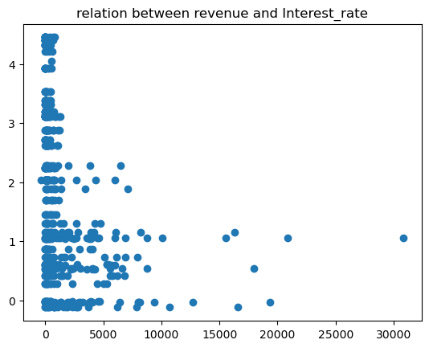

```python
# Scatter plot the relation between revenue and Interest_rate

plt.scatter(allmerge['revt'], allmerge['Interest_rate'])
plt.title('relation between revenue and Interest_rate')
plt.show()
```

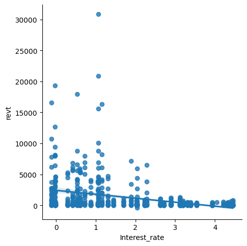

```python
# import seaborn.
import seaborn as sns

#Fit regression in the scatter plot
sns.lmplot(x='Interest_rate',y='revt',data=allmerge,fit_reg=True)
```

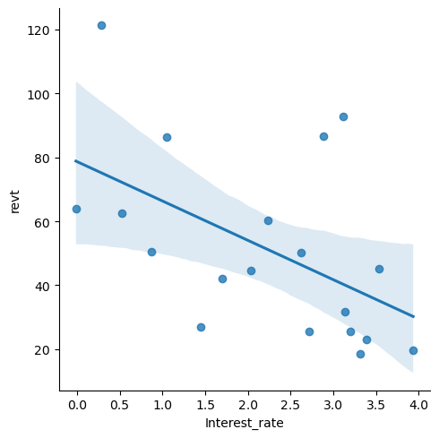

```python
# import seaborn.
import seaborn as sns

#Fit regression in the scatter plot
sns.lmplot(x='Interest_rate',y='revt',data=merge_ind,fit_reg=True)
```

### C) For House Price, the house_price is also Negatively associated with KENNEDY-WILSON HOLDINGS revenue. However, it is also not statistically significant.